# HW1: Using R and the Lavaan Package

Edwin J. Vazquez

This document shows how to use the ‘lavaan’ package to answer the questions in our first assignment.

# Environment set-up

I like to set up the working directory, load the data and the packages needed first. We need the `lavaan` and `semPlot` packages. In this case, though, I’ll enter the data directly into R rather than reading it from a file. Also, the working directory is what I want it to be, so we are good.

```r
# Check working directory
getwd()
```

```
[1] "C:/Users/Edwin/Google Drive/ASU - Spring 2017/FAS 508 - Structural Equation Analysis/SEM - HW 1(1)"
```

```r
# Load the lavaan file
library("lavaan", lib.loc="~/R/win-library/3.2")
library("semPlot", lib.loc="~/R/win-library/3.2")
```

## Set the data

We can enter data as a matrix, or we can enter the lower half of a matrix. However, lavaan likes variance-covariance matrices. The following are the steps necessary to convert from correlation to covariance.

1. We’ll enter the means and sd’s as separate vectors.
2. We’ll enter the correlation matrix.
3. Get the weights to convert from correlation to covariance.

```r
# Enter mean, sd, and matrix
m <- c(0, 0, 0, 0, 0, 0, 0, 0)
sd <- c(1.67332,    0.989949,   1.438749,   1.256981,   1.542725,   1.356466,   1.749286,   1.228821)
b <- sd%*%t(sd)
b
```

```
         [,1]     [,2]     [,3]     [,4]     [,5]     [,6]     [,7]     [,8]
[1,] 2.800000 1.656501 2.407487 2.103331 2.581473 2.269802 2.927115 2.056211
[2,] 1.656501 0.979999 1.424288 1.244347 1.527219 1.342832 1.731704 1.216470
[3,] 2.407487 1.424288 2.069999 1.808480 2.219594 1.951614 2.516783 1.767965
[4,] 2.103331 1.244347 1.808480 1.580001 1.939176 1.705052 2.198819 1.544605
[5,] 2.581473 1.527219 2.219594 1.939176 2.380000 2.092654 2.698667 1.895733
[6,] 2.269802 1.342832 1.951614 1.705052 2.092654 1.840000 2.372847 1.666854
[7,] 2.927115 1.731704 2.516783 2.198819 2.698667 2.372847 3.060002 2.149559
[8,] 2.056211 1.216470 1.767965 1.544605 1.895733 1.666854 2.149559 1.510001
```

```r
coping_cor <- matrix(c(1.000000,0.241473,0.149533,0.166403,0.290532,0.365671,0.252809,0.116720,
                       0.241473,1.000000,0.126379,0.136618,0.275010,0.431923,0.369578,0.057544,
                       0.149533,0.126379,1.000000,0.088472,0.126149,0.107603,0.111253,0.033937,
                       0.166403,0.136618,0.088472,1.000000,0.139234,0.117299,0.118245,0.032371,
                       0.290532,0.275010,0.126149,0.139234,1.000000,0.659450,0.611413,0.358700,
                       0.365671,0.431923,0.107603,0.117299,0.659450,1.000000,0.568937,0.335962,
                       0.252809,0.369578,0.111253,0.118245,0.611413,0.568937,1.000000,0.311692,
                       0.116720,0.057544,0.033937,0.032371,0.358700,0.335962,0.311692,1.000000),
            ncol = 8)
colnames(coping_cor) <- c("BC1", "BC2", "BC3", "BC4",
                          "EC5", "EC6", "EC7", "EC8") # Let's name the columns
coping_cor # Let's check out the matrix
```

```
          BC1      BC2      BC3      BC4      EC5      EC6      EC7      EC8
[1,] 1.000000 0.241473 0.149533 0.166403 0.290532 0.365671 0.252809 0.116720
[2,] 0.241473 1.000000 0.126379 0.136618 0.275010 0.431923 0.369578 0.057544
[3,] 0.149533 0.126379 1.000000 0.088472 0.126149 0.107603 0.111253 0.033937
[4,] 0.166403 0.136618 0.088472 1.000000 0.139234 0.117299 0.118245 0.032371
[5,] 0.290532 0.275010 0.126149 0.139234 1.000000 0.659450 0.611413 0.358700
[6,] 0.365671 0.431923 0.107603 0.117299 0.659450 1.000000 0.568937 0.335962
[7,] 0.252809 0.369578 0.111253 0.118245 0.611413 0.568937 1.000000 0.311692
[8,] 0.116720 0.057544 0.033937 0.032371 0.358700 0.335962 0.311692 1.000000
```

```r
# Abracadabra
b <- sd%*%t(sd)
b
```

```
         [,1]     [,2]     [,3]     [,4]     [,5]     [,6]     [,7]     [,8]
[1,] 2.800000 1.656501 2.407487 2.103331 2.581473 2.269802 2.927115 2.056211
[2,] 1.656501 0.979999 1.424288 1.244347 1.527219 1.342832 1.731704 1.216470
[3,] 2.407487 1.424288 2.069999 1.808480 2.219594 1.951614 2.516783 1.767965
[4,] 2.103331 1.244347 1.808480 1.580001 1.939176 1.705052 2.198819 1.544605
[5,] 2.581473 1.527219 2.219594 1.939176 2.380000 2.092654 2.698667 1.895733
[6,] 2.269802 1.342832 1.951614 1.705052 2.092654 1.840000 2.372847 1.666854
[7,] 2.927115 1.731704 2.516783 2.198819 2.698667 2.372847 3.060002 2.149559
[8,] 2.056211 1.216470 1.767965 1.544605 1.895733 1.666854 2.149559 1.510001
```

```r
coping_cov <- b*coping_cor
coping_cov
```

```
           BC1        BC2        BC3       BC4       EC5       EC6       EC7        EC8
[1,] 2.7999998 0.40000038 0.35999882 0.3500007 0.7500004 0.8300007 0.7400011 0.24000092
[2,] 0.4000004 0.97999902 0.18000011 0.1700002 0.4200005 0.5800001 0.6399997 0.07000056
[3,] 0.3599988 0.18000011 2.06999869 0.1599999 0.2799996 0.2099995 0.2799997 0.05999943
[4,] 0.3500007 0.17000021 0.15999986 1.5800012 0.2699992 0.2000009 0.2599994 0.05000040
[5,] 0.7500004 0.42000052 0.27999957 0.2699992 2.3800004 1.3800007 1.6500002 0.67999938
[6,] 0.8300007 0.58000010 0.20999953 0.2000009 1.3800007 1.8400000 1.3500004 0.55999957
[7,] 0.7400011 0.63999967 0.27999971 0.2599994 1.6500002 1.3500004 3.0600015 0.67000046
[8,] 0.2400009 0.07000056 0.05999943 0.0500004 0.6799994 0.5599996 0.6700005 1.51000105
```

# Model 1

Here, we:

1. Specify the model. Note how notation changes when we prep data for lavaan.
2. Run model this is where lavaan is called. I.e., the `sem` function is a lavaan function. `fit_coping1` is a `lavaan` class object with the output and stuff.
3. Check out the model

```r
# Specify model
coping_model1 <- '
# Latent Variables
F1 =~ BC1 + BC2 + BC3 + BC4 + EC5 + EC6 + EC7 + EC8
'
# Run model
fit_coping1 <- sem(coping_model1,
                   sample.cov = coping_cov,
                   sample.nobs = 500)
```

```
Found more than one class "Model" in cache; using the first, from namespace 'lavaan'
```

```r
# Check out model
summary(fit_coping1, standardized = T)
```

```
lavaan (0.5-22) converged normally after  35 iterations

  Number of observations                           500

  Estimator                                         ML
  Minimum Function Test Statistic               70.917
  Degrees of freedom                                20
  P-value (Chi-square)                           0.000

Parameter Estimates:

  Information                                 Expected
  Standard Errors                             Standard

Latent Variables:
                   Estimate  Std.Err  z-value  P(>|z|)   Std.lv  Std.all
  F1 =~
    BC1               1.000                               0.672    0.402
    BC2               0.668    0.098    6.819    0.000    0.449    0.454
    BC3               0.340    0.109    3.114    0.002    0.228    0.159
    BC4               0.322    0.096    3.352    0.001    0.217    0.173
    EC5               1.834    0.216    8.476    0.000    1.233    0.800
    EC6               1.658    0.195    8.520    0.000    1.115    0.823
    EC7               1.890    0.228    8.276    0.000    1.271    0.727
    EC8               0.741    0.116    6.406    0.000    0.498    0.406

Variances:
                   Estimate  Std.Err  z-value  P(>|z|)   Std.lv  Std.all
   .BC1               2.342    0.153   15.272    0.000    2.342    0.838
   .BC2               0.777    0.051   15.084    0.000    0.777    0.794
   .BC3               2.014    0.128   15.739    0.000    2.014    0.975
   .BC4               1.530    0.097   15.726    0.000    1.530    0.970
   .EC5               0.855    0.082   10.467    0.000    0.855    0.360
   .EC6               0.593    0.062    9.575    0.000    0.593    0.323
   .EC7               1.438    0.115   12.530    0.000    1.438    0.471
   .EC8               1.259    0.082   15.260    0.000    1.259    0.835
    F1                0.452    0.104    4.337    0.000    1.000    1.000
```

```r
inspect(fit_coping1)
```

```
$lambda
    F1
BC1  0
BC2  1
BC3  2
BC4  3
EC5  4
EC6  5
EC7  6
EC8  7

$theta
    BC1 BC2 BC3 BC4 EC5 EC6 EC7 EC8
BC1  8
BC2  0   9
BC3  0   0  10
BC4  0   0   0  11
EC5  0   0   0   0  12
EC6  0   0   0   0   0  13
EC7  0   0   0   0   0   0  14
EC8  0   0   0   0   0   0   0  15

$psi
   F1
F1 16
```

# Model 2

Follow same steps as above.

1. Specify model. Note how we specify our model: First, we need to free up the first weight with `NA*`. This tells lavaan that we don’t what that weight could possibly be, and to please estimated if it’s alright with it. Next, we tell lavaan that we’d like to set the factor variances to 1 using.
2. Run model
3. Check out model

```r
# Specify model
coping_model2 <- '
# Latent Variables
F1 =~ NA*BC1 + BC2 + BC3 + BC4
F2 =~ NA*EC5 + EC6 + EC7 + EC8
# Fix Variances
F1 ~~ 1*F1
F2 ~~ 1*F2
'
# Run model
fit_coping2 <- sem(coping_model2,
                   sample.cov = coping_cov,
                   sample.nobs = 500)
# Specify model
summary(fit_coping2, standardized = T)
```

```
lavaan (0.5-22) converged normally after  24 iterations

  Number of observations                           500

  Estimator                                         ML
  Minimum Function Test Statistic               57.672
  Degrees of freedom                                19
  P-value (Chi-square)                           0.000

Parameter Estimates:

  Information                                 Expected
  Standard Errors                             Standard

Latent Variables:
                   Estimate  Std.Err  z-value  P(>|z|)   Std.lv  Std.all
  F1 =~
    BC1               0.831    0.092    9.027    0.000    0.831    0.497
    BC2               0.545    0.056    9.792    0.000    0.545    0.551
    BC3               0.320    0.079    4.049    0.000    0.320    0.223
    BC4               0.304    0.069    4.408    0.000    0.304    0.242
  F2 =~
    EC5               1.246    0.062   20.107    0.000    1.246    0.809
    EC6               1.108    0.054   20.413    0.000    1.108    0.818
    EC7               1.275    0.072   17.582    0.000    1.275    0.729
    EC8               0.505    0.057    8.873    0.000    0.505    0.411

Covariances:
                   Estimate  Std.Err  z-value  P(>|z|)   Std.lv  Std.all
  F1 ~~
    F2                0.771    0.056   13.661    0.000    0.771    0.771

Variances:
                   Estimate  Std.Err  z-value  P(>|z|)   Std.lv  Std.all
    F1                1.000                               1.000    1.000
    F2                1.000                               1.000    1.000
   .BC1               2.103    0.166   12.661    0.000    2.103    0.753
   .BC2               0.681    0.060   11.390    0.000    0.681    0.696
   .BC3               1.963    0.128   15.364    0.000    1.963    0.950
   .BC4               1.484    0.097   15.275    0.000    1.484    0.941
   .EC5               0.822    0.082   10.038    0.000    0.822    0.346
   .EC6               0.608    0.063    9.665    0.000    0.608    0.331
   .EC7               1.429    0.115   12.441    0.000    1.429    0.468
   .EC8               1.252    0.082   15.236    0.000    1.252    0.831
```

# Compare models

One can go the long and complicated way – which, in R, anyone would be, like, “whaaaa!? long and complicated? in R? Nooooo, never!” – or the sweet and simple, which I’d say is equally surprising.

```r
# Long and complicated - subtract chi square vals and df's
pchisq(13.245, 1, lower = F)
```

```
[1] 0.0002733079
```

```r
# Sweet and simple
anova(fit_coping1, fit_coping2)
```

```
Chi Square Difference Test

            Df   AIC   BIC  Chisq Chisq diff Df diff Pr(>Chisq)
fit_coping2 19 13143 13214 57.672
fit_coping1 20 13154 13221 70.917     13.245       1  0.0002732 ***
---
Signif. codes:  0 ‘***’ 0.001 ‘**’ 0.01 ‘*’ 0.05 ‘.’ 0.1 ‘ ’ 1
```

# Get them plots!

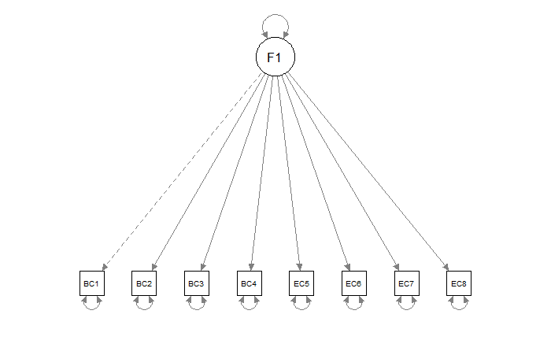

```r
semPaths(fit_coping1)
```

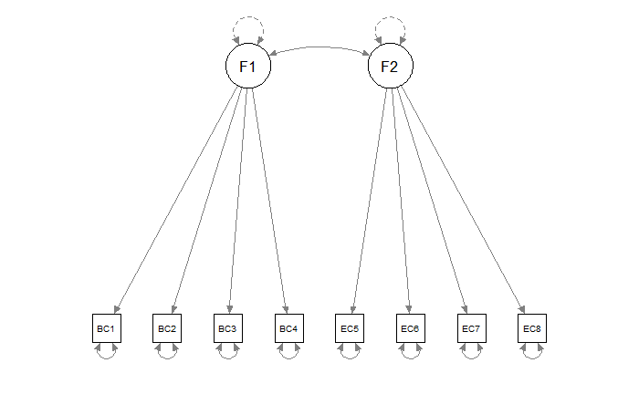

```r
semPaths(fit_coping2)
```